# Week_6_demo

Katz

2/21/2021

### Script for class discussion on multiple regression

### Explore the child aggression data set

```r
ca_df <- read.table("./data/ChildAggression.dat", header = TRUE)
```

Method 1 for quickly getting summary statistics for the data you have, using the built-in summary() function

```r
summary(ca_df)
```

```
##    Aggression          Television       Computer_Games
##  Min.   :-1.295608   Min.   :-1.46012   Min.   :-1.1538345
##  1st Qu.:-0.174279   1st Qu.:-0.18206   1st Qu.:-0.1687007
##  Median :-0.005548   Median :-0.01247   Median :-0.0001997
##  Mean   :-0.005011   Mean   :-0.02758   Mean   : 0.0103812
##  3rd Qu.: 0.149611   3rd Qu.: 0.14983   3rd Qu.: 0.1881810
##  Max.   : 1.178823   Max.   : 0.98162   Max.   : 1.6175039
##  Sibling_Aggression       Diet          Parenting_Style
##  Min.   :-1.433127   Min.   :-1.28490   Min.   :-4.46041
##  1st Qu.:-0.156414   1st Qu.:-0.16136   1st Qu.:-0.58008
##  Median : 0.008459   Median : 0.00934   Median : 0.02736
##  Mean   : 0.008275   Mean   : 0.01162   Mean   : 0.00000
##  3rd Qu.: 0.185136   3rd Qu.: 0.18708   3rd Qu.: 0.51784
##  Max.   : 1.103671   Max.   : 1.22383   Max.   : 3.99326
```

Method 2, using the describe() function from the psych package

```r
describe(ca_df)
```

```
##                    vars   n  mean   sd median trimmed  mad   min  max range
## Aggression            1 666 -0.01 0.32  -0.01   -0.01 0.24 -1.30 1.18  2.47
## Television            2 666 -0.03 0.31  -0.01   -0.02 0.25 -1.46 0.98  2.44
## Computer_Games        3 666  0.01 0.34   0.00    0.00 0.27 -1.15 1.62  2.77
## Sibling_Aggression    4 666  0.01 0.33   0.01    0.01 0.26 -1.43 1.10  2.54
## Diet                  5 666  0.01 0.34   0.01    0.01 0.26 -1.28 1.22  2.51
## Parenting_Style       6 666  0.00 1.00   0.03    0.01 0.82 -4.46 3.99  8.45
##                     skew kurtosis   se
## Aggression         -0.02     1.61 0.01
## Television         -0.36     1.34 0.01
## Computer_Games      0.25     1.60 0.01
## Sibling_Aggression -0.17     1.40 0.01
## Diet               -0.12     1.51 0.01
## Parenting_Style    -0.22     1.67 0.04
```

Spot check: where do the “se” values come from?

# now that we have seen some of the numbers, let’s try to visualize some of these data

# let’s try to visualize the data while we’re at it

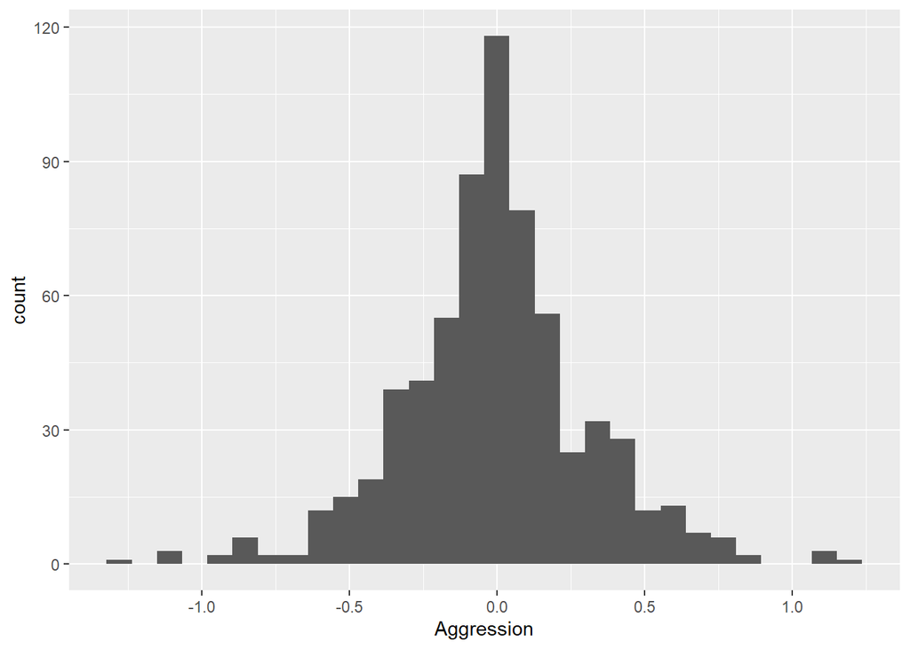

```r
ca_df %>%
  ggplot(aes(x = Aggression)) +
  geom_histogram()
```

We could do this for each of our variables or we could try something a little fancier by using the pivot_longer() function to make a longer dataframe and plot everything at once

First, create the long dataframe. After running this command, it’s a good idea to view the new data frame to make sure this did what you intended

```r
ca_df_long <- ca_df %>%
  pivot_longer(cols = Aggression:Parenting_Style, names_to = "variable_name", values_to = "variable_value")
```

After making sure everything looks in order, run the same plot command with the addition of a facet.

Note that the fill = variable_name tells R to color the plot with different colors by variable_name and the theme(…) tells R to get rid of the legend that automatically shows up

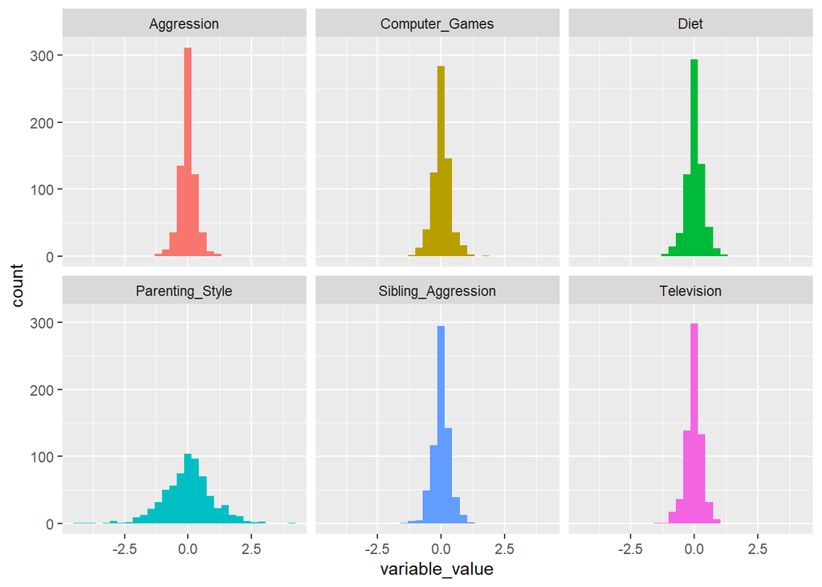

```r
ca_df_long %>%
  ggplot(aes(x = variable_value, fill = variable_name)) +
  geom_histogram() +
  facet_wrap(variable_name ~.) +
  theme(legend.position = "none")
```

Let’s try a different kind of visualization: the empirical cumulative distribution function (eCDF) (sounds fancy, but it’s not bad)

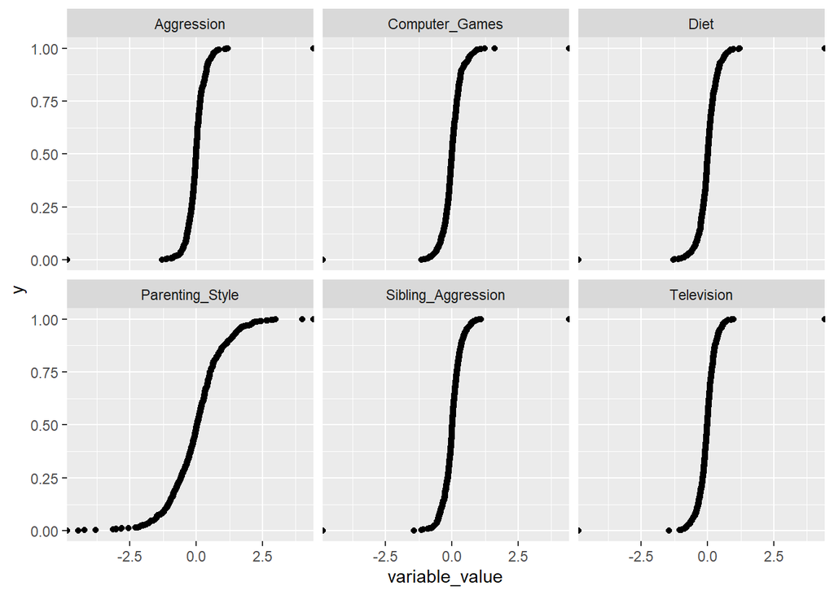

```r
ca_df_long %>%
  ggplot(aes(x = variable_value)) +
  stat_ecdf(geom = "point") +
  facet_wrap(variable_name ~.)
```

It looks like a bunch of distorted s shapes. In order to understand what is going on here, we should take a brief detour into the world of cumulative distribution functions (CDFs), eCDFs, and eventually QQ plots. This detour is at the end of the markdown file.

Now we can try a third way of visualizing our data - QQ plots!

As before, we can plot each variable with separate calls or plot them all together with the long data frame

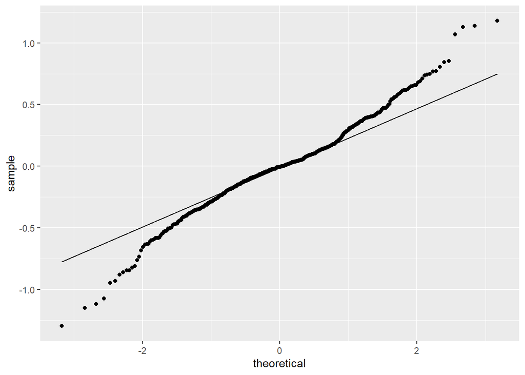

```r
ca_df %>%
  ggplot(aes(sample=Aggression)) +
  stat_qq() +
  stat_qq_line()
```

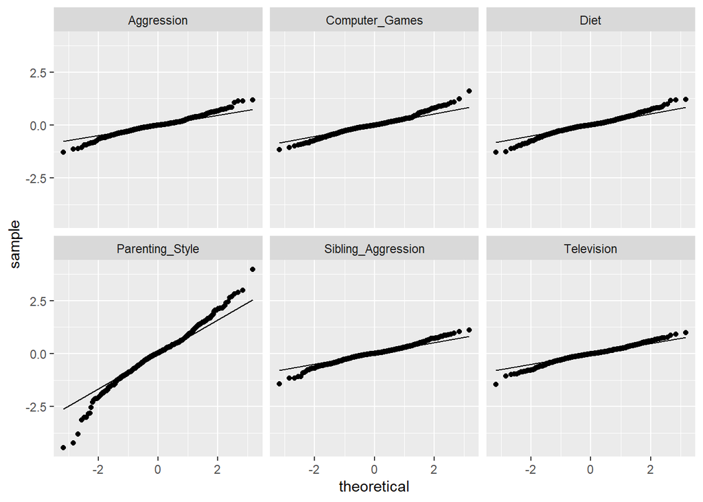

```r
ca_df_long %>%
  ggplot(aes(sample=variable_value)) +
  stat_qq() +
  stat_qq_line() +
  facet_wrap(variable_name ~ .)
```

## Multiple regression

Let’s create a model of child aggression as a function of parenting style and sibling aggression

```r
model_fam <- lm(Aggression ~ Parenting_Style + Sibling_Aggression, data = ca_df)
```

Run the summary on the model

```r
summary(model_fam)
```

```
##
## Call:
## lm(formula = Aggression ~ Parenting_Style + Sibling_Aggression,
##     data = ca_df)
##
## Residuals:
##      Min       1Q   Median       3Q      Max
## -1.09755 -0.17180  0.00092  0.15405  1.23037
##
## Coefficients:
##                     Estimate Std. Error t value Pr(>|t|)
## (Intercept)        -0.005784   0.012065  -0.479    0.632
## Parenting_Style     0.061984   0.012257   5.057 5.51e-07 ***
## Sibling_Aggression  0.093409   0.037505   2.491    0.013 *
## ---
## Signif. codes:  0 '***' 0.001 '**' 0.01 '*' 0.05 '.' 0.1 ' ' 1
##
## Residual standard error: 0.3113 on 663 degrees of freedom
## Multiple R-squared:  0.05325,    Adjusted R-squared:  0.05039
## F-statistic: 18.64 on 2 and 663 DF,  p-value: 1.325e-08
```

Let’s create another model of child aggression as a function of computer games and television.

```r
model_screens <- lm(Aggression ~ Computer_Games + Television, data = ca_df)

summary(model_screens)
```

```
##
## Call:
## lm(formula = Aggression ~ Computer_Games + Television, data = ca_df)
##
## Residuals:
##      Min       1Q   Median       3Q      Max
## -1.05234 -0.15191 -0.00512  0.15156  1.24062
##
## Coefficients:
##                 Estimate Std. Error t value Pr(>|t|)
## (Intercept)    -0.002879   0.012132  -0.237 0.812526
## Computer_Games  0.153874   0.035845   4.293 2.03e-05 ***
## Television      0.135263   0.039546   3.420 0.000664 ***
## ---
## Signif. codes:  0 '***' 0.001 '**' 0.01 '*' 0.05 '.' 0.1 ' ' 1
##
## Residual standard error: 0.3115 on 663 degrees of freedom
## Multiple R-squared:  0.05149,    Adjusted R-squared:  0.04862
## F-statistic: 17.99 on 2 and 663 DF,  p-value: 2.455e-08
```

Now let’s see what the full model looks like with all five predictors

```r
model_all <- lm(Aggression ~ Parenting_Style + Sibling_Aggression + Diet + Computer_Games + Television,
                data = ca_df)
summary(model_all)
```

```
##
## Call:
## lm(formula = Aggression ~ Parenting_Style + Sibling_Aggression +
##     Diet + Computer_Games + Television, data = ca_df)
##
## Residuals:
##      Min       1Q   Median       3Q      Max
## -1.12629 -0.15253 -0.00421  0.15222  1.17669
##
## Coefficients:
##                     Estimate Std. Error t value Pr(>|t|)
## (Intercept)        -0.004988   0.011983  -0.416 0.677350
## Parenting_Style     0.056648   0.014557   3.891 0.000110 ***
## Sibling_Aggression  0.081684   0.038780   2.106 0.035550 *
## Diet               -0.109054   0.038076  -2.864 0.004315 **
## Computer_Games      0.142161   0.036920   3.851 0.000129 ***
## Television          0.032916   0.046057   0.715 0.475059
## ---
## Signif. codes:  0 '***' 0.001 '**' 0.01 '*' 0.05 '.' 0.1 ' ' 1
##
## Residual standard error: 0.3071 on 660 degrees of freedom
## Multiple R-squared:  0.08258,    Adjusted R-squared:  0.07563
## F-statistic: 11.88 on 5 and 660 DF,  p-value: 5.025e-11
```

We can get the output from the summary() function but as a tibble instead:

```r
broom::tidy(model_all, conf.int = TRUE)
```

```
## # A tibble: 6 x 7
##   term               estimate std.error statistic  p.value conf.low conf.high
##   <chr>                 <dbl>     <dbl>     <dbl>    <dbl>    <dbl>     <dbl>
## 1 (Intercept)        -0.00499    0.0120    -0.416 0.677    -0.0285     0.0185
## 2 Parenting_Style     0.0566     0.0146     3.89  0.000110  0.0281     0.0852
## 3 Sibling_Aggression  0.0817     0.0388     2.11  0.0355    0.00554    0.158
## 4 Diet               -0.109      0.0381    -2.86  0.00432  -0.184     -0.0343
## 5 Computer_Games      0.142      0.0369     3.85  0.000129  0.0697     0.215
## 6 Television          0.0329     0.0461     0.715 0.475    -0.0575     0.123
```

We can also get summary statistics like the R^2, F-statistics, and AIC from the glance() function in the Broom package

```r
broom::glance(model_all)
```

```
## # A tibble: 1 x 12
##   r.squared adj.r.squared sigma statistic  p.value    df logLik   AIC   BIC
##       <dbl>         <dbl> <dbl>     <dbl>    <dbl> <dbl>  <dbl> <dbl> <dbl>
## 1    0.0826        0.0756 0.307      11.9 5.02e-11     5  -156.  325.  357.
## # ... with 3 more variables: deviance <dbl>, df.residual <int>, nobs <int>
```

Let’s stop here to interpret what the model output is telling us(specifically, the coefficient estimates, the standard errors, the p values, and the R^2 values).

Notice the Television p value and standard errors (especially how the estimate is so close to zero, and its 95% confidence interval crosses 0)

We can also have R handle factors automatically in a regression model for us.

First, we will generate a new factor for the child aggression data - the handedness of the child (left vs right).

This code generates a random handedness for each of the 666 students and assigns it to a new column in ca_df

```r
handed_levels <- c("left", "right")
handed_vector <- sample(handed_levels, size = nrow(ca_df), replace = TRUE, prob = c(0.4, 0.6))
ca_df$Handedness <- handed_vector
```

Check to make sure we have all the predictor names correct to add into the linear model.

```r
names(ca_df)
```

```
## [1] "Aggression"         "Television"         "Computer_Games"
## [4] "Sibling_Aggression" "Diet"               "Parenting_Style"
## [7] "Handedness"
```

```r
model_all_3 <- lm(Aggression ~ Parenting_Style + Sibling_Aggression + Television + Computer_Games + Diet + Handedness, data = ca_df)
```

Check the model summary and notice how the Handedness predictor variable was handled.

```r
summary(model_all_3)
```

```
##
## Call:
## lm(formula = Aggression ~ Parenting_Style + Sibling_Aggression +
##     Television + Computer_Games + Diet + Handedness, data = ca_df)
##
## Residuals:
##      Min       1Q   Median       3Q      Max
## -1.11697 -0.14994  0.00142  0.15505  1.16114
##
## Coefficients:
##                     Estimate Std. Error t value Pr(>|t|)
## (Intercept)         0.009274   0.018919   0.490 0.624153
## Parenting_Style     0.056905   0.014560   3.908 0.000103 ***
## Sibling_Aggression  0.079914   0.038824   2.058 0.039946 *
## Television          0.034119   0.046076   0.740 0.459267
## Computer_Games      0.143967   0.036967   3.894 0.000108 ***
## Diet               -0.110221   0.038097  -2.893 0.003940 **
## Handednessright    -0.023735   0.024364  -0.974 0.330320
## ---
## Signif. codes:  0 '***' 0.001 '**' 0.01 '*' 0.05 '.' 0.1 ' ' 1
##
## Residual standard error: 0.3071 on 659 degrees of freedom
## Multiple R-squared:  0.0839, Adjusted R-squared:  0.07556
## F-statistic: 10.06 on 6 and 659 DF,  p-value: 1.189e-10
```

```r
lm(Aggression ~ ., data=ca_df)
```

```
##
## Call:
## lm(formula = Aggression ~ ., data = ca_df)
##
## Coefficients:
##        (Intercept)          Television      Computer_Games  Sibling_Aggression
##           0.009274            0.034119            0.143967            0.079914
##               Diet     Parenting_Style     Handednessright
##          -0.110221            0.056905           -0.023735
```

### Assumption testing

Note: A lot of the things we are doing here can be accomplished with the augment() function in the broom package

Check for correlation between adjacent residual terms using Durbin-Watson test

```r
dwt(model_all)
```

```
##  lag Autocorrelation D-W Statistic p-value
##    1      0.04218005      1.912808   0.298
##  Alternative hypothesis: rho != 0
```

Now let’s go back and check for influential cases following the procedure Field does in the textbook.

```r
ca_df$residuals <- resid(model_all) # notice how this is the same as looking at View(model_all) and then residuals or model_all$residuals
model_all$residuals
```

[output not shown]

[output cut: 213 more lines]

[output not shown]

```r
ca_df$standardized.residuals <- rstandard(model_all)
ca_df$studentized.residuals <- rstudent(model_all)
ca_df$cooks.distance <- cooks.distance(model_all)
ca_df$dfbeta <- dfbeta(model_all)
ca_df$dffit <- dffits(model_all)
ca_df$leverage <- hatvalues(model_all)
ca_df$covariance.ratios <- covratio(model_all)
```

Now that we have all of the extra model fit statistics calculated, we can add a new olumn using a different method than what he does in the textbook (but this accomplishes the same task).

We are using a combination of mutate() and case_when() instead of the traditional logical test subsetting that we see in the bookon pp. 289-290

```r
ca_df <- ca_df %>%
  mutate(large.residual = case_when(standardized.residuals > 2 | standardized.residuals < -2 ~ TRUE,
                                    abs(standardized.residuals) <= 2 ~ FALSE))
```

Now let’s just look at the observations where there was a large residual (absolute value > 2)

```r
ca_df %>% filter(large.residual == TRUE) %>% head()
```

```
##   Aggression  Television Computer_Games Sibling_Aggression       Diet
## 1  0.7711534 -0.03287184     0.70991822        0.576836667 -0.0229903
## 2 -0.9309839 -0.14695730     0.58503832        0.143914123  0.1341567
## 3  0.8437696 -0.53337187     0.62674291        0.006193792 -0.0542531
## 4 -0.8604237 -0.32734996    -0.10228524        0.088454410  0.3403472
## 5  0.7374707  0.05104538     0.06804261        0.742478946  0.3607529
## 6  0.6158280 -0.17945254    -0.14381635        0.337002793 -0.5992525
##   Parenting_Style Handedness  residuals standardized.residuals
## 1      -1.2481665       left  0.6973813               2.289855
## 2      -1.0470961      right -0.9421375              -3.081966
## 3       0.2386578       left  0.7572738               2.484122
## 4      -0.6988965       left -0.7606374              -2.483667
## 5       0.9243197      right  0.6574374               2.152417
## 6      -1.0334894       left  0.6128345               2.006389
##   studentized.residuals cooks.distance dfbeta.(Intercept)
```

[output cut: 27 more lines]

There’s a problem here because we don’t preserve observation numbers. In general, it might be a good idea to give each observation an ID with something like

```r
dim(ca_df)[1]
```

```
## [1] 666
```

```r
ca_df <- ca_df %>%
  mutate(ID = seq(1:dim(ca_df)[1]))
```

In the tidyverse, there is an even simpler way to do this with the rowid_to_column() function!

```r
ca_df <- ca_df %>%
  rowid_to_column(var = "participant_id")
```

Now we can run the filter again and see which observations have large residuals

```r
ca_df %>% filter(large.residual == TRUE) %>% view()
```

Plot the residuals against the fitted values

```r
ca_df$fitted <- model_all$fitted.values
```

First, plot the distribution of the residuals by themselves

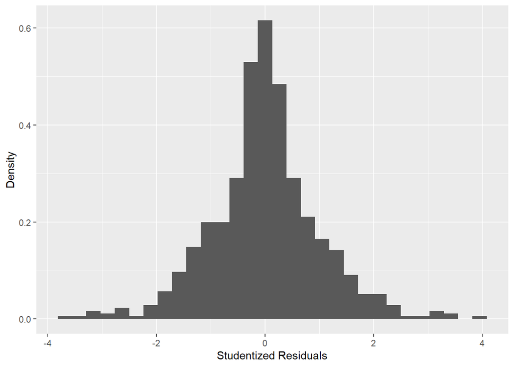

```r
histogram <- ca_df %>%
  ggplot(aes(x = studentized.residuals)) +
  geom_histogram(aes(y = ..density..)) +
  labs(x = "Studentized Residuals",
       y = "Density")
histogram
```

Now let’s add a normal density on top of that for comparison

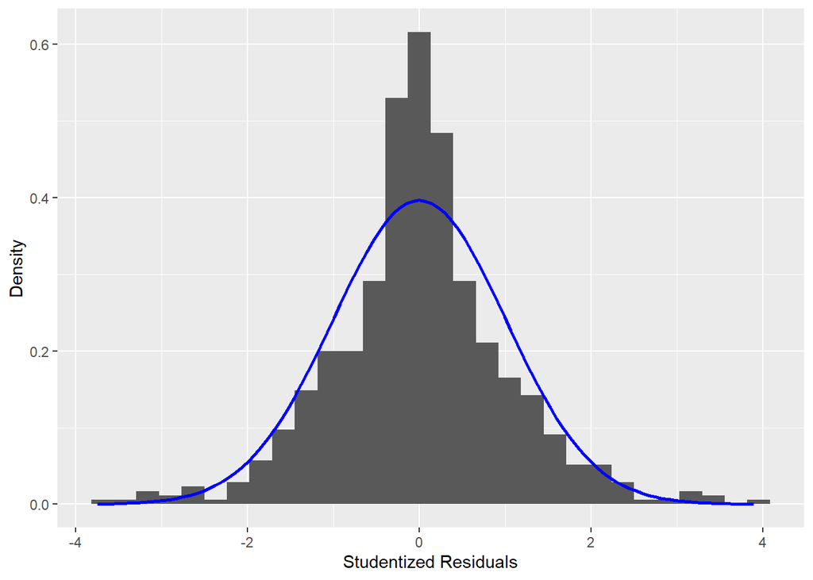

```r
histogram + stat_function(fun = dnorm,
                          args = list(mean = mean(ca_df$studentized.residuals, na.rm = TRUE),
                                      sd = sd(ca_df$studentized.residuals, na.rm = TRUE)),
                          color = "blue", size = 1)
```

Second, plot the residuals against the fitted values to make sure there are no systematic patterns

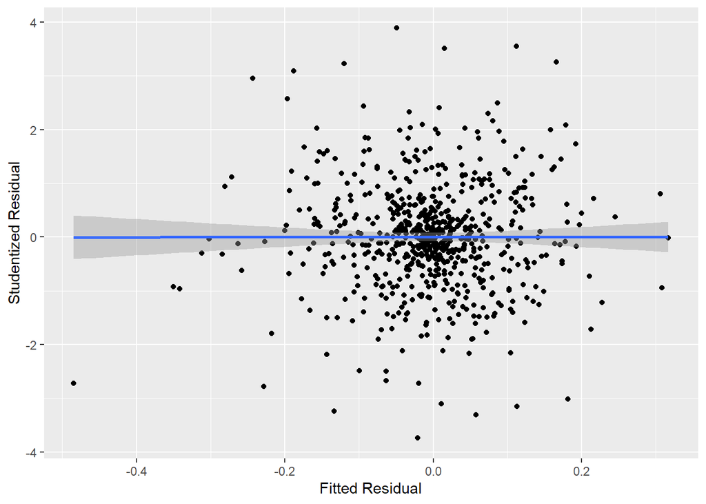

```r
ca_df %>%
  ggplot(aes(x = fitted, y = studentized.residuals)) +
  geom_point() +
  geom_smooth(method = "lm") +
  labs(x = "Fitted Residual",
       y = "Studentized Residual")
```

We can also skip all the fancy code from the book and use the plot() function on the model.

R knows that this means we want to plot four fit plots

```r
par(mfrow=c(2,2)) # this changes the arrangement for the plots to show two rows and two columns of plots
```

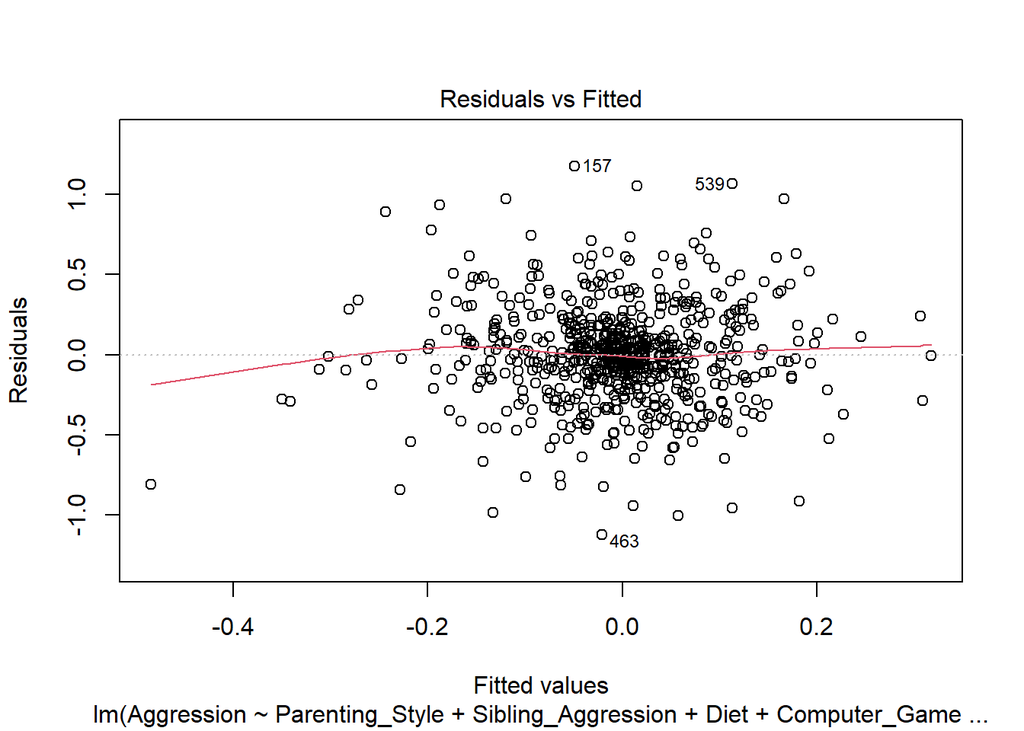

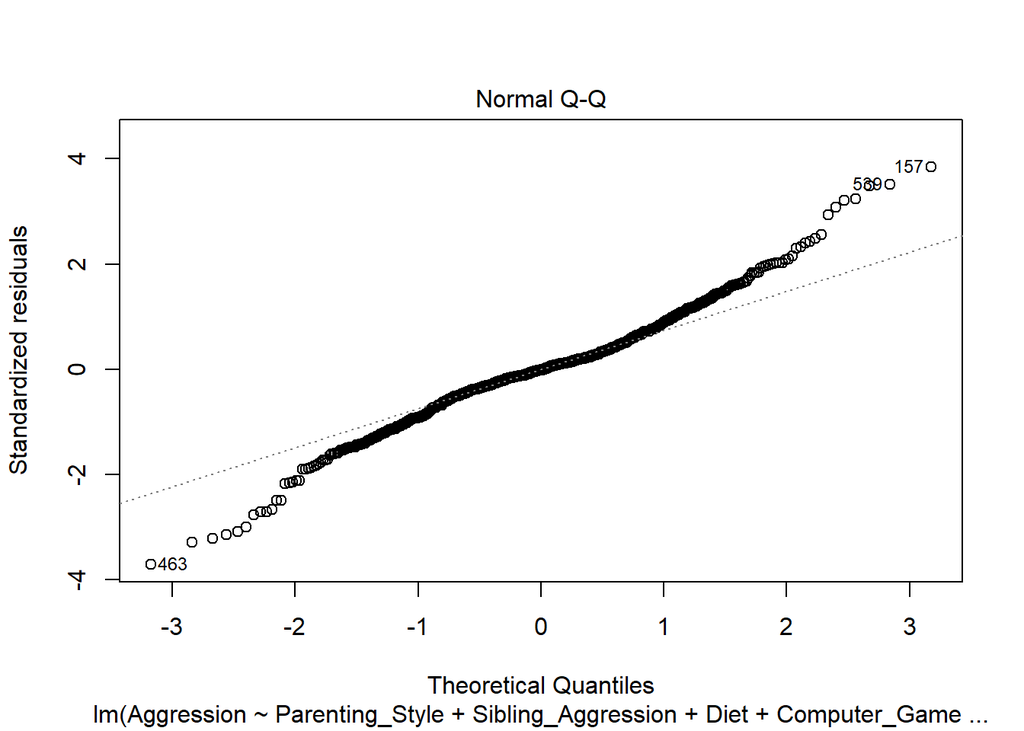

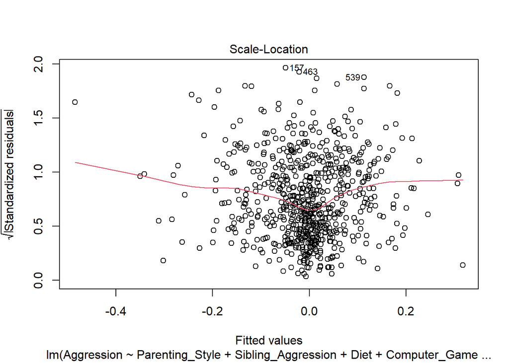

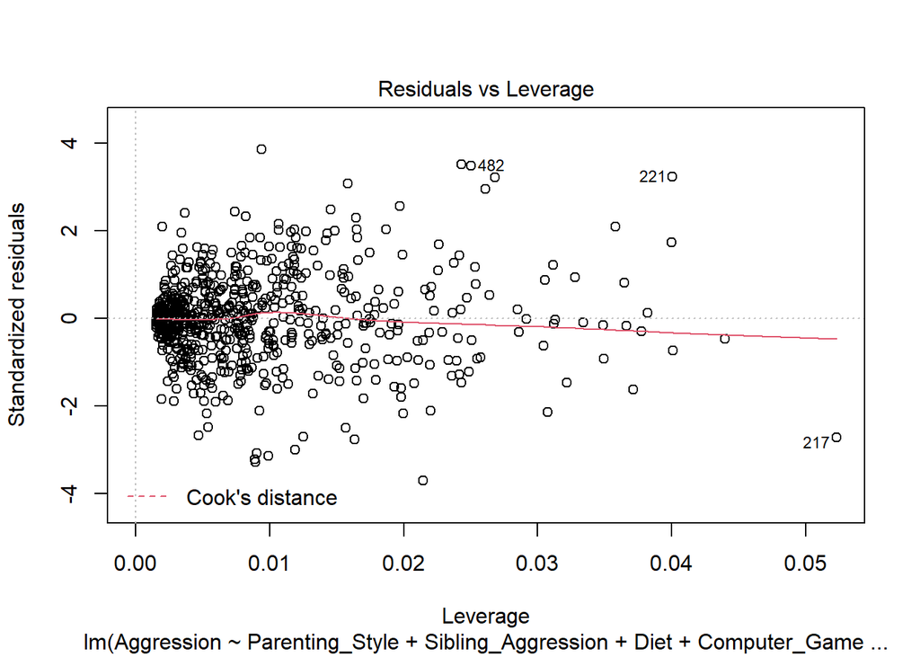

```r
plot(model_all)
```

```r
par(mfrow=c(1,1)) # this changes the plotting arrangement back to the default of one plot at a time
```

Note that we could also create a model that uses all our covariates as predictors with the following call

```r
model_all_2 <- lm(Aggression ~ ., data=ca_df)
```

Inspect the results to make sure it is giving the same results as before

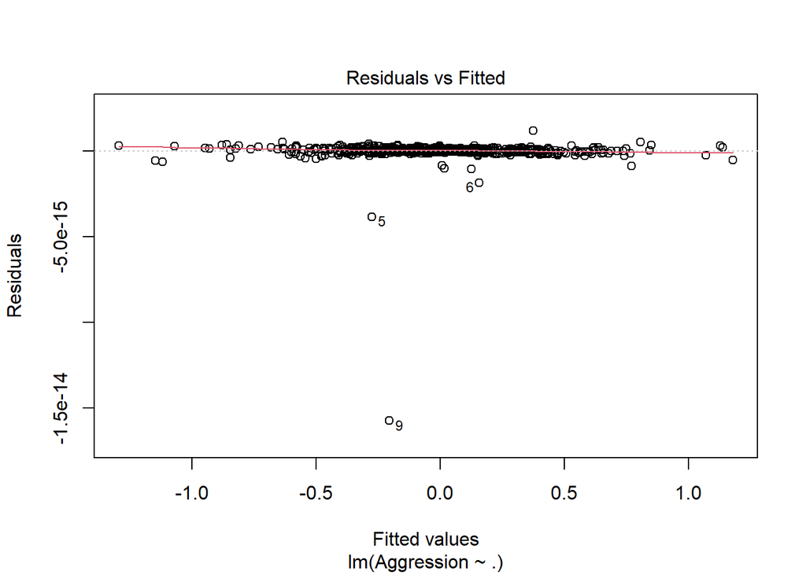

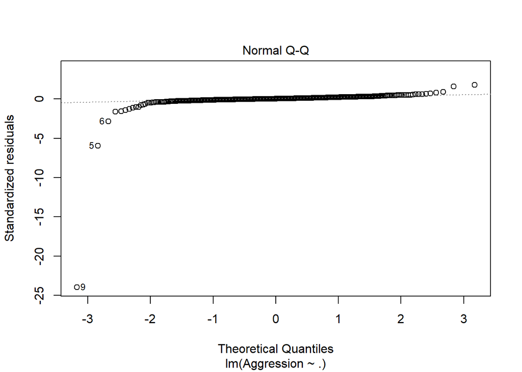

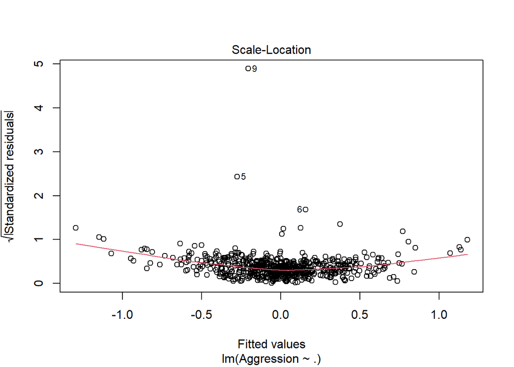

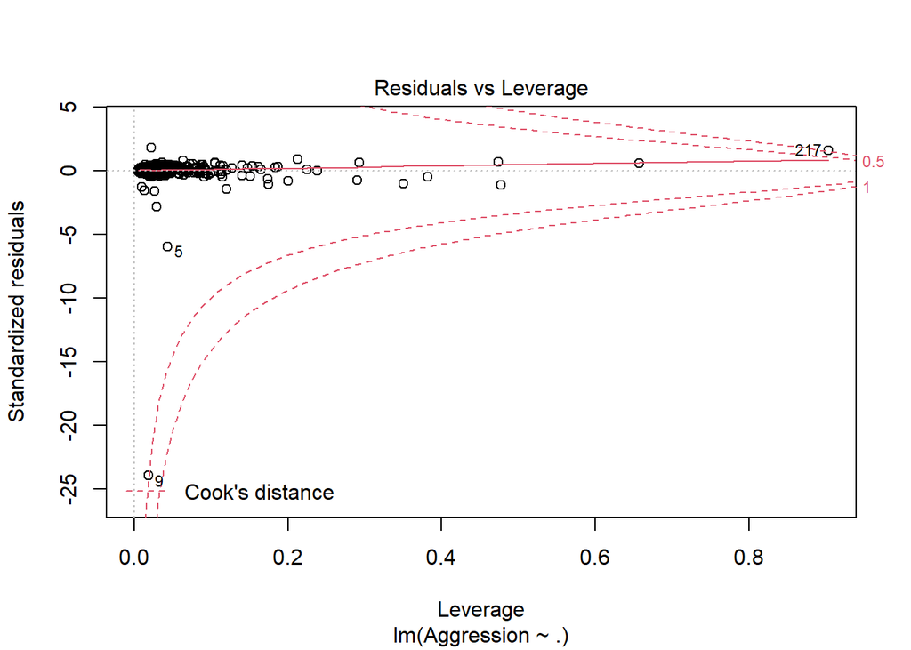

```r
plot(model_all_2)
```

```r
summary(model_all_2)
```

```
##
## Call:
## lm(formula = Aggression ~ ., data = ca_df)
##
## Residuals:
##        Min         1Q     Median         3Q        Max
## -1.574e-14 -3.460e-17  3.140e-17  1.068e-16  1.193e-15
##
## Coefficients: (2 not defined because of singularities)
##                            Estimate Std. Error    t value Pr(>|t|)
## (Intercept)              -4.988e-03  3.571e-15 -1.397e+12  < 2e-16 ***
## participant_id            7.370e-19  1.357e-19  5.432e+00 7.89e-08 ***
## Television                3.292e-02  1.011e-16  3.254e+14  < 2e-16 ***
## Computer_Games            1.422e-01  8.131e-17  1.748e+15  < 2e-16 ***
## Sibling_Aggression        8.168e-02  8.517e-17  9.591e+14  < 2e-16 ***
## Diet                     -1.091e-01  8.407e-17 -1.297e+15  < 2e-16 ***
## Parenting_Style           5.665e-02  3.202e-17  1.769e+15  < 2e-16 ***
## Handednessright           0.000e+00  5.313e-17  0.000e+00    1.000
## residuals                 1.000e+00  6.849e-12  1.460e+11  < 2e-16 ***
## standardized.residuals   -1.493e-12  4.093e-12 -3.650e-01    0.715
## studentized.residuals    -8.825e-15  9.874e-15 -8.940e-01    0.372
## cooks.distance            6.988e-15  9.252e-15  7.550e-01    0.450
## dfbeta(Intercept)         1.573e-09  4.319e-09  3.640e-01    0.716
## dfbetaParenting_Style     2.390e-14  4.955e-14  4.820e-01    0.630
## dfbetaSibling_Aggression  1.301e-11  3.574e-11  3.640e-01    0.716
## dfbetaDiet                1.829e-11  5.019e-11  3.640e-01    0.716
## dfbetaComputer_Games      1.633e-11  4.484e-11  3.640e-01    0.716
## dfbetaTelevision         -4.339e-11  1.191e-10 -3.640e-01    0.716
## dffit                     4.748e-15  9.268e-15  5.120e-01    0.609
## leverage                 -2.839e-15  5.835e-15 -4.870e-01    0.627
## covariance.ratios         5.345e-16  3.555e-15  1.500e-01    0.881
## large.residualTRUE       -3.836e-17  2.022e-16 -1.900e-01    0.850
## ID                               NA         NA         NA       NA
## fitted                           NA         NA         NA       NA
## ---
## Signif. codes:  0 '***' 0.001 '**' 0.01 '*' 0.05 '.' 0.1 ' ' 1
##
## Residual standard error: 6.628e-16 on 644 degrees of freedom
## Multiple R-squared:      1,  Adjusted R-squared:      1
## F-statistic: 7.353e+30 on 21 and 644 DF,  p-value: < 2.2e-16
```

Check how augment() works and which parts of the above it replicates

```r
augmented_model_all <- augment(model_all)
```

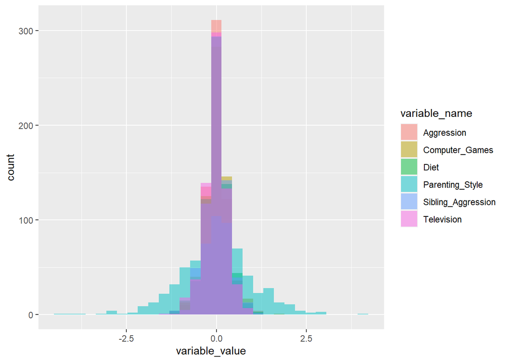

```r
ca_df_long %>%
  ggplot(aes(x = variable_value, fill = variable_name)) +
  geom_histogram(position = "identity", alpha = 0.5)
```

### Detour: Cumulative Distribution Function (CDF), empirical CDF, and QQ Plot Discussion

Our goal here is to visualize the cumulative distribution function for a normal distribution as a stepping stone toward undestanding QQ plots. We will use plots of the empirical cumulative distribution function (eCDF)

As a way to visualize our data. Although we have not discussed eCDFs before, they are another tool you can use to visualize the distribution of quantitative data.

We will also look at the effect of sample size on the kinds of plots that we may make when visualizing the distribution of data.

First, let’s generate some data to help us see what these concepts are all about.

**Note** that We are generating data to make things easier on ourselves - we know the underlying data-generating process. So that lets us form an expectation of what *should* happen. These kinds of toy examples can be helpful for building an intuition about these concepts that we can then use in our own work.

```r
df_1 <- tibble(x = round(rnorm(n = 25, mean = 0, sd = 1), digits = 1), samp_size = rep(x = 25, times = 25))
df_2 <- tibble(x = round(rnorm(n = 50, mean = 0, sd = 1), digits = 1), samp_size = rep(x = 50, times = 50))
df_3 <- tibble(x = round(rnorm(n = 100, mean = 0, sd = 1), digits = 1), samp_size = rep(x = 100, times = 100))
df_4 <- tibble(x = round(rnorm(n = 200, mean = 0, sd = 1), digits = 1), samp_size = rep(x = 200, times = 200))
df_5 <- tibble(x = round(rnorm(n = 500, mean = 0, sd = 1), digits = 1), samp_size = rep(x = 500, times = 500))
```

Combine the generated data together into one data frame to make it easy to plot everything in one ggplot call

```r
sample_df <- bind_rows(df_1, df_2, df_3, df_4, df_5)
```